# Applied Econometrics and Data Science with R - Introduction to Automation in R

Felix Degenhardt & Sophie Wagner

2025-10-10

# Introduction

In data science, automation is key to improving efficiency and reproducibility. Today, we’ll explore how to automate tasks in R using **loops** and **functions**. These are the fundamental building blocks that will help you avoid repetitive code and reduce errors.

Why should you care about this? Found [here](https://www.shilaan.com/post/writing-reproducible-manuscripts-in-r/).

[video not shown]

**Real-world scenarios where automation helps:**

- You need to run the same regression with 10 different outcome variables
- You want to test your random forest with different training data subsets
- You need to compare model performance across different pre-processing strategies
- You want to tune parameters in a custom way that built-in functions don’t support

Also, you might need to share your analysis or pass it on to a colleague (or to course instructors). By automating the process, you ensure that the same steps are applied consistently each time, reducing the risk of human error. For instance, parameter tuning in machine learning models can be automated, ensuring that the same methods are applied across different datasets or projects, making your work more reproducible and easier to validate.

By the end of this session, you’ll be able to write functions and loops that make these tasks simple and reproducible.

# Load Required Packages

```r
# Install and load packages -- Try to understand those loops and functions after the session!
my_packages <- c("tidyverse", "ranger", "caret", "rpart", "rpart.plot",
                 "pROC", "kableExtra", "broom")

for(p in my_packages){
  if(!require(p, character.only = TRUE)) {
    install.packages(p)
  }
  library(p, character.only = TRUE)
}
```

# Load and Prepare Data

```r
# Load the dataset
data <- read.csv("../00_data/survey/survey_processed.csv")

# Check the data
head(data)
```

|  | id | abiturnote | mathenote | statistiknote_w1 | fachsemester | erstfach | risk_affine | alkohol | sport | kochen | bio | paar_schuhe | risiko | geduldig | loc_verlauf | loc_schicksal | loc_einfluss | loc_hartearbeit | wegdauer | einkommen | partei | geburtsbundesland | fleisch | uebungen_w1 | Partei | geburtsbundesland_name | age | female | male | … |
| --- | --- | --- | --- | --- | --- | --- | --- | --- | --- | --- | --- | --- | --- | --- | --- | --- | --- | --- | --- | --- | --- | --- | --- | --- | --- | --- | --- | --- | --- | --- |
| 1 | 1 | 2.5 | 2.700000 | 2.5 | 8 | 1 | 1 | 2 | 3 | 3 | 60 | 4 | 11 | 9 | 7 | 1 | 2 | 7 | 15 | 1000 | Sonstige | 4 | 2000 | 14 | Sonstige | Brandenburg | 21 | 0 | 1 | … |
| 2 | 2 | 1.8 | 3.000000 | 2.0 | 2 | 1 | 1 | 1 | 3 | 4 | 30 | 7 | 11 | 4 | 7 | 3 | 5 | 5 | 7 | 1800 | Grüne | NA | 2800 | 14 | Grüne | NA | 22 | 0 | 1 | … |
| 3 | 3 | 2.3 | 1.700000 | 1.7 | 2 | 1 | 0 | 1 | 2 | 2 | 35 | 4 | 6 | 9 | 6 | 2 | 3 | 6 | 17 | 800 | SPD | 3 | 800 | 14 | SPD | Berlin | 25 | 0 | 1 | … |
| 4 | 4 | 1.4 | 3.000000 | 2.7 | 2 | 12 | 1 | 1 | 3 | 3 | 30 | 4 | 7 | 7 | 6 | 6 | 2 | 3 | 5 | 400 | Keine | 2 | 150 | 13 | Keine | Bayern | 26 | 1 | 0 | … |
| 5 | 5 | 2.4 | 5.000000 | 2.0 | 2 | 12 | 0 | 1 | 2 | 3 | 50 | 2 | 5 | 9 | 6 | 2 | 4 | 7 | 60 | 900 | Linke | 10 | 10 | 14 | Linke | Nordrhein-Westfalen | 21 | 0 | 1 | … |
| 6 | 6 | 2.2 | 2.146667 | 3.7 | 6 | 17 | 0 | 1 | 1 | 3 | 25 | 12 | 4 | 8 | 6 | 2 | 3 | 6 | 90 | NA | Grüne | 4 | 500 | 14 | Grüne | Brandenburg | 20 | 1 | 0 | … |

```r
dim(data)
```

```
## [1] 235  34
```

# Part 1: Loops

Loops allow you to repeat the same operation multiple times without copy-pasting code.

## For Loops

A `for` loop iterates over a sequence of values.

```r
# Simple example: Calculate squares
for (i in 1:5) {
  result <- i^2
  print(paste("The square of", i, "is", result))
}
```

```
## [1] "The square of 1 is 1"
## [1] "The square of 2 is 4"
## [1] "The square of 3 is 9"
## [1] "The square of 4 is 16"
## [1] "The square of 5 is 25"
```

## Storing Loop Results

Usually, you want to save the results from your loop. Here’s how:

```r
# Create empty vector to store results
squares <- numeric(5)

# Fill the vector using a loop
for (i in 1:5) {
  squares[i] <- i^2
}

squares
```

```
## [1]  1  4  9 16 25
```

For more complex objects (like regression models), use a list:

```r
# Create empty list to store models
models <- list()

# Store different objects in the list
for (i in 1:3) {
  # Use different numbers of observations from our data
  data_subset <- data[1:(50*i), ]
  models[[i]] <- lm(statistiknote_w1 ~ female + fachsemester, data = data_subset)
}

# Access the second model
summary(models[[2]])
```

```
##
## Call:
## lm(formula = statistiknote_w1 ~ female + fachsemester, data = data_subset)
##
## Residuals:
##      Min       1Q   Median       3Q      Max
## -2.02252 -0.43003 -0.02252  0.53296  1.87748
##
## Coefficients:
##              Estimate Std. Error t value Pr(>|t|)
## (Intercept)   2.94585    0.16753  17.584   <2e-16 ***
## female       -0.08194    0.16763  -0.489    0.626
## fachsemester  0.03834    0.04332   0.885    0.378
## ---
## Signif. codes:  0 '***' 0.001 '**' 0.01 '*' 0.05 '.' 0.1 ' ' 1
##
## Residual standard error: 0.7888 on 97 degrees of freedom
## Multiple R-squared:  0.01158,    Adjusted R-squared:  -0.008797
## F-statistic: 0.5683 on 2 and 97 DF,  p-value: 0.5683
```

### 5-Min Classroom Task: Loops

Write a loop that:

1. Calculates the mean of `statistiknote_w1` for different sample sizes: first 50, 100, 150, 200, and 250 rows of the data
2. Stores each mean in a vector
3. Prints the results

**Bonus:** Can you also store the standard deviation for each subset?

```r
# Your code here
means <- numeric(5)
sample_sizes <- c(50, 100, 150, 200, 250)

for (i in 1:length(sample_sizes)) {
  # Fill in the loop
}
```

# Part 2: Functions

Functions let you write code once and use it many times with different inputs.

## Basic Function Structure

```r
# Simple function
calculate_square <- function(x) {
  result <- x^2
  return(result)
}

# Use the function
calculate_square(5)
```

```
## [1] 25
```

```r
calculate_square(10)
```

```
## [1] 100
```

## Functions with Multiple Arguments

```r
# Function with multiple inputs and a default value
power_function <- function(x, power = 2) {
  result <- x^power
  return(result)
}

# Use default power (2)
power_function(5)
```

```
## [1] 25
```

```r
# Specify different power
power_function(5, power = 3)
```

```
## [1] 125
```

## Functions with If-Else Logic

```r
# Function with conditional logic
describe_number <- function(x) {
  if (x < 0) {
    return("negative")
  } else if (x == 0) {
    return("zero")
  } else {
    return("positive")
  }
}

describe_number(-5)
```

```
## [1] "negative"
```

```r
describe_number(0)
```

```
## [1] "zero"
```

```r
describe_number(10)
```

```
## [1] "positive"
```

### 5-Min Classroom Task: Functions

Write a function called `grade_exam()` that:

1. Takes a numeric grade (0-100) as input
2. Returns “Excellent” if grade >= 90
3. Returns “Good” if grade >= 70
4. Returns “Pass” if grade >= 50
5. Returns “Fail” otherwise

Test it with grades: 95, 75, 55, 40

```r
# Your code here
grade_exam <- function(grade) {
  # Fill in the function
}

# Test it
grade_exam(95)
grade_exam(75)
grade_exam(55)
grade_exam(40)
```

# Part 3: Automating Machine Learning Tasks

Now let’s see how automation helps with machine learning workflows.

## Preparing Data for ML

```r
# Prepare clean dataset
data_ml <- data %>%
  select(risk_affine, female, statistiknote_w1, fachsemester,
         erstfach_name, alkohol) %>%
  drop_na() %>%
  mutate_at(c("female", "risk_affine", "alkohol", "erstfach_name"), as.factor)

# Check dimensions
dim(data_ml)
```

```
## [1] 224   6
```

## Why Automate in Machine Learning?

In ML, you often need to test many different approaches:

- **Different parameter values**: What’s the best mtry? The best number of trees?
- **Different sample sizes**: Does more training data always help?
- **Different pre-processing**: Should we restrict the age range? Remove outliers?

Testing these manually would mean copy-pasting code dozens of times. **Automation lets you test systematically and compare results easily.**

## Example 1: Testing Different Parameters

Let’s say you want to test different `mtry` values (how many variables to consider at each split):

```r
# Set up - do this ONCE before the loop
set.seed(123)
trainIndex <- createDataPartition(data_ml$risk_affine, p = 0.7, list = FALSE)
trainData <- data_ml[trainIndex, ]
testData <- data_ml[-trainIndex, ]

# Define mtry values to test
mtry_values <- c(2, 3, 4, 5)

# Store results
results <- data.frame(mtry = numeric(), accuracy = numeric())

# Loop through different mtry values
for (m in mtry_values) {
  # Train model with different mtry
  model <- ranger(
    risk_affine ~ female + statistiknote_w1 + fachsemester + erstfach_name + alkohol,
    data = trainData,
    num.trees = 150,
    mtry = m,
    probability = TRUE
  )

  # Predict on test set
  predictions <- predict(model, data = testData)
  pred_class <- ifelse(predictions$predictions[, "1"] > 0.5, "1", "0")
  pred_class <- factor(pred_class, levels = levels(testData$risk_affine))

  # Calculate accuracy
  accuracy <- mean(pred_class == testData$risk_affine)

  # Store result
  results <- rbind(results, data.frame(mtry = m, accuracy = accuracy))

  print(paste("mtry =", m, "| Accuracy =", round(accuracy, 3)))
}
```

```
## [1] "mtry = 2 | Accuracy = 0.507"
## [1] "mtry = 3 | Accuracy = 0.507"
## [1] "mtry = 4 | Accuracy = 0.493"
## [1] "mtry = 5 | Accuracy = 0.522"
```

```r
# View all results
results
```

| mtry | accuracy |
| --- | --- |
| 2 | 0.5074627 |
| 3 | 0.5074627 |
| 4 | 0.4925373 |
| 5 | 0.5223881 |

**Key insight:** We split the data once, then test different mtry values on the same split. This lets us see which mtry works best for this particular train/test combination.

## Example 2: Nested Loops for Multiple Parameters

What if you want to test **both** training size AND mtry? Use nested loops:

```r
# What to test
train_sizes <- c(0.5, 0.7, 0.9)
mtry_values <- c(2, 3, 4)

# Store results
tuning_results <- data.frame(train_size = numeric(), mtry = numeric(), accuracy = numeric())

# Outer loop: training sizes
for (train_prop in train_sizes) {

  # Create train/test split for this training size
  set.seed(123)
  trainIndex <- createDataPartition(data_ml$risk_affine, p = train_prop, list = FALSE)
  trainData <- data_ml[trainIndex, ]
  testData <- data_ml[-trainIndex, ]

  # Inner loop: mtry values
  for (m in mtry_values) {

    # Train model with this combination of parameters
    model <- ranger(
      risk_affine ~ female + statistiknote_w1 + fachsemester + erstfach_name + alkohol,
      data = trainData,
      num.trees = 150,
      mtry = m,
      probability = TRUE
    )

    # Make predictions on test set
    predictions <- predict(model, data = testData)
    pred_class <- ifelse(predictions$predictions[, "1"] > 0.5, "1", "0")
    pred_class <- factor(pred_class, levels = levels(testData$risk_affine))

    # Calculate accuracy
    accuracy <- mean(pred_class == testData$risk_affine)

    # Store result
    tuning_results <- rbind(tuning_results,
                           data.frame(train_size = train_prop, mtry = m, accuracy = accuracy))

    # Print progress
    print(paste("Train size:", train_prop, "| mtry:", m, "| Accuracy:", round(accuracy, 3)))
  }
}
```

```
## [1] "Train size: 0.5 | mtry: 2 | Accuracy: 0.509"
## [1] "Train size: 0.5 | mtry: 3 | Accuracy: 0.5"
## [1] "Train size: 0.5 | mtry: 4 | Accuracy: 0.5"
## [1] "Train size: 0.7 | mtry: 2 | Accuracy: 0.507"
## [1] "Train size: 0.7 | mtry: 3 | Accuracy: 0.507"
## [1] "Train size: 0.7 | mtry: 4 | Accuracy: 0.493"
## [1] "Train size: 0.9 | mtry: 2 | Accuracy: 0.636"
## [1] "Train size: 0.9 | mtry: 3 | Accuracy: 0.591"
## [1] "Train size: 0.9 | mtry: 4 | Accuracy: 0.636"
```

```r
# View all results
tuning_results %>%
  kbl(digits = 3) %>%
  kable_styling(bootstrap_options = "striped", full_width = FALSE)
```

| train_size | mtry | accuracy |
| --- | --- | --- |
| 0.5 | 2 | 0.509 |
| 0.5 | 3 | 0.500 |
| 0.5 | 4 | 0.500 |
| 0.7 | 2 | 0.507 |
| 0.7 | 3 | 0.507 |
| 0.7 | 4 | 0.493 |
| 0.9 | 2 | 0.636 |
| 0.9 | 3 | 0.591 |
| 0.9 | 4 | 0.636 |

```r
# Find best combination
best <- tuning_results[which.max(tuning_results$accuracy), ]
print(paste("Best: train_size =", best$train_size, "| mtry =", best$mtry, "| Accuracy =", round(best$accuracy, 3)))
```

```
## [1] "Best: train_size = 0.9 | mtry = 2 | Accuracy = 0.636"
```

**The power of nested loops:** We tested 9 combinations (3 × 3) with just a few lines of code!

## Visualizing Tuning Results

You’ll learn to create such nice graphs in the next session!

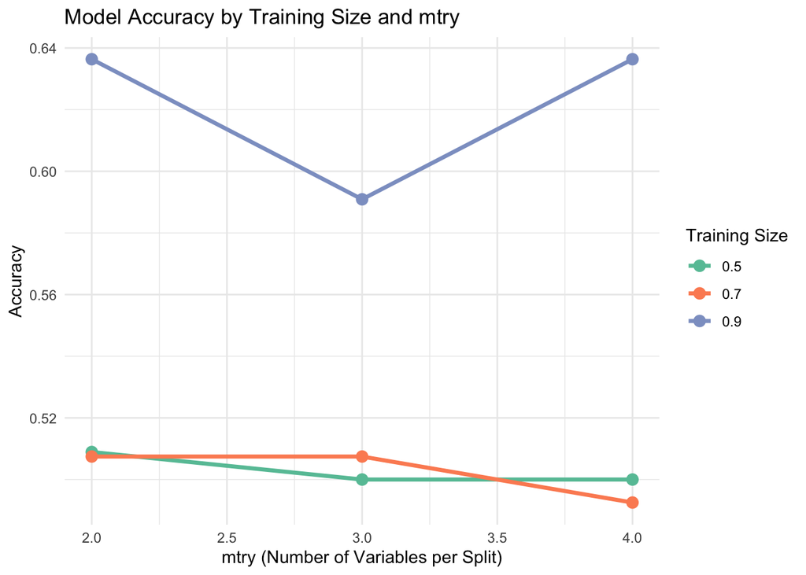

```r
# Plot accuracy as lines for each training size
ggplot(tuning_results, aes(x = mtry, y = accuracy,
                           color = as.factor(train_size),
                           group = train_size)) +
  geom_line(linewidth = 1.2) +
  geom_point(size = 3) +
  labs(title = "Model Accuracy by Training Size and mtry",
       x = "mtry (Number of Variables per Split)",
       y = "Accuracy",
       color = "Training Size") +
  theme_minimal() +
  scale_color_brewer(palette = "Set2")
```

Now you can easily see which combination works best! You can also vary the number of trees, and basically every parameter you have!

## Testing Different Pre-Processing Strategies

In practice, you often want to test how robust your model is to different pre-processing decisions. For example:

- What if we remove outliers vs. keep them?
- What if we restrict the sample to certain age groups?
- What if we treat missing values differently?

Let’s automate testing different pre-processing approaches and see how they affect model performance.

### Example: Testing Different Age Restrictions

Suppose you want to see how your model performs when trained on different age groups:

```r
# First, let's add age back to our data for this example
data_ml_age <- data %>%
  select(risk_affine, female, statistiknote_w1, fachsemester,
         erstfach_name, alkohol, age) %>%
  drop_na() %>%
  mutate_at(c("female", "risk_affine", "alkohol", "erstfach_name"), as.factor)

# Function to test model with different age restrictions
test_age_restrictions <- function(formula, data, age_ranges, seed = 123) {

  results <- data.frame(
    age_restriction = character(),
    n_observations = numeric(),
    accuracy = numeric(),
    stringsAsFactors = FALSE
  )

  for (i in 1:nrow(age_ranges)) {
    # Filter data by age
    min_age <- age_ranges$min[i]
    max_age <- age_ranges$max[i]
    data_filtered <- data %>% filter(age >= min_age & age <= max_age)

    # Skip if too few observations
    if (nrow(data_filtered) < 50) {
      print(paste("Skipping age", min_age, "-", max_age, ": too few observations"))
      next
    }

    # Split and train
    set.seed(seed)
    trainIndex <- createDataPartition(data_filtered$risk_affine,
                                      p = 0.7, list = FALSE)
    trainData <- data_filtered[trainIndex, ]
    testData <- data_filtered[-trainIndex, ]

    model <- ranger(formula, data = trainData, num.trees = 150,
                   probability = TRUE, seed = seed)

    # Predict and evaluate
    predictions <- predict(model, data = testData)
    pred_class <- ifelse(predictions$predictions[, "1"] > 0.5, "1", "0")
    pred_class <- factor(pred_class, levels = levels(testData$risk_affine))
    accuracy <- mean(pred_class == testData$risk_affine)

    # Store results
    results <- rbind(results,
                    data.frame(
                      age_restriction = paste(min_age, "-", max_age),
                      n_observations = nrow(data_filtered),
                      accuracy = accuracy
                    ))
  }

  return(results)
}

## now let's look at our age distribution
summary(data_ml_age$age)
```

```
##    Min. 1st Qu.  Median    Mean 3rd Qu.    Max.
##    1.00   21.00   23.00   23.61   25.00   53.00
```

```r
# Define age ranges to test. In your code, don't hard-code the age ranges!
age_ranges <- data.frame(
  min = c(18, 20),
  max = c(54, 24)
)

# Test different age restrictions
age_results <- test_age_restrictions(
  formula = risk_affine ~ female + statistiknote_w1 + fachsemester + alkohol,
  data = data_ml_age,
  age_ranges = age_ranges
)

# Display results
age_results %>%
  kbl(digits = 3) %>%
  kable_styling(bootstrap_options = "striped", full_width = FALSE)
```

| age_restriction | n_observations | accuracy |
| --- | --- | --- |
| 18 - 54 | 222 | 0.631 |
| 20 - 24 | 149 | 0.545 |

This helps us understand if our model works better for certain age groups, or if we should use the full sample.

### 5-Min Classroom Task: Automizing age restrictions

Use the `test_age_restrictions` function to assess how accurate your model would be for people over 25. Do you need to edit the function itself or just use different input?

```r
# Your code here
```

### Motivation: Other Pre-Processing Strategies to Test

You could use the same approach to test:

**Outlier handling:** - Keep all data vs. remove outliers (e.g., values beyond 3 standard deviations) - Winsorize extreme values vs. remove them - Different outlier definitions for different variables

**Sample restrictions:** - Only certain majors vs. all majors - Only students who work vs. all students - First-year students vs. more experienced students

**Missing data strategies:** - Different imputation methods (mean, median, mode) - Complete case analysis vs. imputation - Dropping variables with too many missing values

The key is: **write a function once, test many strategies automatically, and let the data tell you what works best!**

# Part 4: Automating Regression Analysis (Optional)

Now let’s apply these concepts to real data analysis tasks.

## Manual Approach (Don’t Do This!)

Imagine you want to run regressions with three different outcome variables:

```r
# This is repetitive and error-prone!
model1 <- lm(statistiknote_w1 ~ risk_affine + female + fachsemester, data = data)
model2 <- lm(mathenote ~ risk_affine + female + fachsemester, data = data)
model3 <- lm(abiturnote ~ risk_affine + female + fachsemester, data = data)

summary(model1)
```

```
##
## Call:
## lm(formula = statistiknote_w1 ~ risk_affine + female + fachsemester,
##     data = data)
##
## Residuals:
##      Min       1Q   Median       3Q      Max
## -1.93028 -0.60023  0.07998  0.63557  1.96972
##
## Coefficients:
##              Estimate Std. Error t value Pr(>|t|)
## (Intercept)   2.93889    0.12808  22.947   <2e-16 ***
## risk_affine   0.02144    0.10536   0.203    0.839
## female       -0.01026    0.10759  -0.095    0.924
## fachsemester -0.01502    0.02579  -0.583    0.561
## ---
## Signif. codes:  0 '***' 0.001 '**' 0.01 '*' 0.05 '.' 0.1 ' ' 1
##
## Residual standard error: 0.7994 on 231 degrees of freedom
## Multiple R-squared:  0.001711,   Adjusted R-squared:  -0.01125
## F-statistic: 0.132 on 3 and 231 DF,  p-value: 0.941
```

## Better: Use a Loop

```r
# Define outcomes and predictors
outcomes <- c("statistiknote_w1", "mathenote", "abiturnote")
predictors <- c("risk_affine", "female", "fachsemester")

# Create empty list for models
models <- list()

# Loop through outcomes
for (i in 1:length(outcomes)) {
  # Create formula
  formula_text <- paste(outcomes[i], "~", paste(predictors, collapse = " + "))
  formula_obj <- as.formula(formula_text)

  # Fit model
  models[[i]] <- lm(formula_obj, data = data)

  # Print which model we just fit
  print(paste("Fitted model for:", outcomes[i]))
}
```

```
## [1] "Fitted model for: statistiknote_w1"
## [1] "Fitted model for: mathenote"
## [1] "Fitted model for: abiturnote"
```

```r
# Name the list elements
names(models) <- outcomes

# Check one model
summary(models$statistiknote_w1)
```

```
##
## Call:
## lm(formula = formula_obj, data = data)
##
## Residuals:
##      Min       1Q   Median       3Q      Max
## -1.93028 -0.60023  0.07998  0.63557  1.96972
##
## Coefficients:
##              Estimate Std. Error t value Pr(>|t|)
## (Intercept)   2.93889    0.12808  22.947   <2e-16 ***
## risk_affine   0.02144    0.10536   0.203    0.839
## female       -0.01026    0.10759  -0.095    0.924
## fachsemester -0.01502    0.02579  -0.583    0.561
## ---
## Signif. codes:  0 '***' 0.001 '**' 0.01 '*' 0.05 '.' 0.1 ' ' 1
##
## Residual standard error: 0.7994 on 231 degrees of freedom
## Multiple R-squared:  0.001711,   Adjusted R-squared:  -0.01125
## F-statistic: 0.132 on 3 and 231 DF,  p-value: 0.941
```

## Even Better: Use a Function

```r
# Function to run a regression
run_regression <- function(outcome_var, predictor_vars, dataset) {
  # Create formula
  formula_text <- paste(outcome_var, "~", paste(predictor_vars, collapse = " + "))
  formula_obj <- as.formula(formula_text)

  # Fit model
  model <- lm(formula_obj, data = dataset)

  return(model)
}

# Use the function
model_stats <- run_regression("statistiknote_w1", predictors, data)
summary(model_stats)
```

```
##
## Call:
## lm(formula = formula_obj, data = dataset)
##
## Residuals:
##      Min       1Q   Median       3Q      Max
## -1.93028 -0.60023  0.07998  0.63557  1.96972
##
## Coefficients:
##              Estimate Std. Error t value Pr(>|t|)
## (Intercept)   2.93889    0.12808  22.947   <2e-16 ***
## risk_affine   0.02144    0.10536   0.203    0.839
## female       -0.01026    0.10759  -0.095    0.924
## fachsemester -0.01502    0.02579  -0.583    0.561
## ---
## Signif. codes:  0 '***' 0.001 '**' 0.01 '*' 0.05 '.' 0.1 ' ' 1
##
## Residual standard error: 0.7994 on 231 degrees of freedom
## Multiple R-squared:  0.001711,   Adjusted R-squared:  -0.01125
## F-statistic: 0.132 on 3 and 231 DF,  p-value: 0.941
```

```r
# Use it in a loop for multiple outcomes
models_func <- list()
for (outcome in outcomes) {
  models_func[[outcome]] <- run_regression(outcome, predictors, data)
}
```

## Creating a Simple Results Table

Now let’s extract key coefficients from all models and put them in a table:

```r
# Use broom package to tidy model output
library(broom)

# Extract coefficients for one model
tidy(models_func$statistiknote_w1)
```

| term | estimate | std.error | statistic | p.value |
| --- | --- | --- | --- | --- |
| (Intercept) | 2.93888846 | 0.12807563 | 22.94650822 | 1.673127e-61 |
| risk_affine | 0.02143539 | 0.10536135 | 0.20344639 | 8.389652e-01 |
| female | -0.01025899 | 0.10758582 | -0.09535635 | 9.241145e-01 |
| fachsemester | -0.01502372 | 0.02578819 | -0.58258132 | 5.607434e-01 |

```r
# Now do it for all models using a loop
all_results <- data.frame()

for (outcome in outcomes) {
  # Get tidy results
  model_tidy <- tidy(models_func[[outcome]])

  # Add outcome name
  model_tidy$outcome <- outcome

  # Combine with previous results
  all_results <- rbind(all_results, model_tidy)
}

# Show results for one coefficient across all models
all_results %>%
  filter(term == "risk_affine") %>%
  select(outcome, estimate, std.error, p.value) %>%
  kbl(digits = 3) %>%
  kable_styling(bootstrap_options = "striped", full_width = FALSE)
```

| outcome | estimate | std.error | p.value |
| --- | --- | --- | --- |
| statistiknote_w1 | 0.021 | 0.105 | 0.839 |
| mathenote | 0.193 | 0.150 | 0.200 |
| abiturnote | 0.071 | 0.075 | 0.343 |

# Part 5: Quick Introduction to `purrr` (Optional)

The `purrr` package provides a faster way to apply functions. It’s like `lapply()` but with more consistent syntax. Here’s a quick comparison:

```r
# Using a regular loop
squares_loop <- numeric(5)
for (i in 1:5) {
  squares_loop[i] <- i^2
}

# Using lapply (base R)
squares_lapply <- lapply(1:5, function(x) x^2)
squares_lapply <- unlist(squares_lapply)

# Using map from purrr (similar to lapply)
library(purrr)
squares_map <- map_dbl(1:5, ~ .x^2)

# All give the same result
squares_loop
```

```
## [1]  1  4  9 16 25
```

```r
squares_lapply
```

```
## [1]  1  4  9 16 25
```

```r
squares_map
```

```
## [1]  1  4  9 16 25
```

`purrr` is useful but not essential - loops and `lapply()` work just fine for most tasks!

# Summary

**What we learned:**

1. **Loops** let you repeat operations without copy-pasting code
   - Use `for` loops to iterate over sequences
   - Store results in vectors or lists
2. **Functions** make your code reusable
   - Write once, use many times with different inputs
   - Include if-else logic for flexibility
   - Add default values for common parameters
3. **Automation in practice:**
   - Run multiple regressions automatically
   - Create formatted results tables
   - Test different model parameters systematically
   - Compare pre-processing strategies
4. **`purrr`** is a faster alternative to loops
   - Similar to base R’s `lapply()`
   - More consistent syntax
   - Optional - loops work fine!

**Key principle:** If you’re copying and pasting code with small changes, you should write a function or loop instead!

# Sources

- Wickham, H., & Grolemund, G. (2017). *R for Data Science: Import, Tidy, Transform, Visualize, and Model Data*. O’Reilly Media.
- Kuhn, M. (2008). Building predictive models in R using the caret package. *Journal of Statistical Software*, 28(5), 1-26.
- Wright, M. N., & Ziegler, A. (2017). ranger: A fast implementation of random forests for high dimensional data in C++ and R. *Journal of Statistical Software*, 77(1), 1-17.
- Wickham, H. (2019). *Advanced R* (2nd ed.). Chapman and Hall/CRC.